# STAT 508 Final Project EDA

Callum Arnold

# Set Up

```r
library(tidyverse)
library(here)
library(hrbrthemes)
library(janitor)
library(corrplot)
library(skimr)
library(cowplot)

RNGkind(sample.kind = "Rounding")
set.seed(1)

theme_set(theme_ipsum())
```

```r
credit <- as_tibble(read_csv(here("data", "creditcard.csv")))
```

```r
credit <- credit %>%
  mutate(
    Class = case_when(
      Class == 0 ~ "None",
      Class == 1 ~ "Fraud"
    )
  ) %>%
  mutate(across(.cols = Class, .fns = factor))
```

# EDA

```r
head(credit)
```

```
## # A tibble: 6 x 31
##    Time     V1      V2    V3     V4      V5      V6      V7      V8     V9
##   <dbl>  <dbl>   <dbl> <dbl>  <dbl>   <dbl>   <dbl>   <dbl>   <dbl>  <dbl>
## 1     0 -1.36  -0.0728 2.54   1.38  -0.338   0.462   0.240   0.0987  0.364
## 2     0  1.19   0.266  0.166  0.448  0.0600 -0.0824 -0.0788  0.0851 -0.255
## 3     1 -1.36  -1.34   1.77   0.380 -0.503   1.80    0.791   0.248  -1.51
## 4     1 -0.966 -0.185  1.79  -0.863 -0.0103  1.25    0.238   0.377  -1.39
## 5     2 -1.16   0.878  1.55   0.403 -0.407   0.0959  0.593  -0.271   0.818
## 6     2 -0.426  0.961  1.14  -0.168  0.421  -0.0297  0.476   0.260  -0.569
## # … with 21 more variables: V10 <dbl>, V11 <dbl>, V12 <dbl>, V13 <dbl>,
## #   V14 <dbl>, V15 <dbl>, V16 <dbl>, V17 <dbl>, V18 <dbl>, V19 <dbl>,
## #   V20 <dbl>, V21 <dbl>, V22 <dbl>, V23 <dbl>, V24 <dbl>, V25 <dbl>,
## #   V26 <dbl>, V27 <dbl>, V28 <dbl>, Amount <dbl>, Class <fct>
```

## Variable Summary

```r
anyNA(credit)
```

```
## [1] FALSE
```

```r
skim(credit)
```

Data summary

| Name | credit |
| --- | --- |
| Number of rows | 284807 |
| Number of columns | 31 |
| _______________________ |  |
| Column type frequency: |  |
| factor | 1 |
| numeric | 30 |
| ________________________ |  |
| Group variables | None |

**Variable type: factor**

| skim_variable | n_missing | complete_rate | ordered | n_unique | top_counts |
| --- | --- | --- | --- | --- | --- |
| Class | 0 | 1 | FALSE | 2 | Non: 284315, Fra: 492 |

**Variable type: numeric**

| skim_variable | n_missing | complete_rate | mean | sd | p0 | p25 | p50 | p75 | p100 | hist |
| --- | --- | --- | --- | --- | --- | --- | --- | --- | --- | --- |
| Time | 0 | 1 | 94813.86 | 47488.15 | 0.00 | 54201.50 | 84692.00 | 139320.50 | 172792.00 | ▃▇▅▆▇ |
| V1 | 0 | 1 | 0.00 | 1.96 | -56.41 | -0.92 | 0.02 | 1.32 | 2.45 | ▁▁▁▁▇ |
| V2 | 0 | 1 | 0.00 | 1.65 | -72.72 | -0.60 | 0.07 | 0.80 | 22.06 | ▁▁▁▇▁ |
| V3 | 0 | 1 | 0.00 | 1.52 | -48.33 | -0.89 | 0.18 | 1.03 | 9.38 | ▁▁▁▁▇ |
| V4 | 0 | 1 | 0.00 | 1.42 | -5.68 | -0.85 | -0.02 | 0.74 | 16.88 | ▂▇▁▁▁ |
| V5 | 0 | 1 | 0.00 | 1.38 | -113.74 | -0.69 | -0.05 | 0.61 | 34.80 | ▁▁▁▇▁ |
| V6 | 0 | 1 | 0.00 | 1.33 | -26.16 | -0.77 | -0.27 | 0.40 | 73.30 | ▁▇▁▁▁ |
| V7 | 0 | 1 | 0.00 | 1.24 | -43.56 | -0.55 | 0.04 | 0.57 | 120.59 | ▁▇▁▁▁ |
| V8 | 0 | 1 | 0.00 | 1.19 | -73.22 | -0.21 | 0.02 | 0.33 | 20.01 | ▁▁▁▇▁ |
| V9 | 0 | 1 | 0.00 | 1.10 | -13.43 | -0.64 | -0.05 | 0.60 | 15.59 | ▁▁▇▁▁ |
| V10 | 0 | 1 | 0.00 | 1.09 | -24.59 | -0.54 | -0.09 | 0.45 | 23.75 | ▁▁▇▁▁ |
| V11 | 0 | 1 | 0.00 | 1.02 | -4.80 | -0.76 | -0.03 | 0.74 | 12.02 | ▁▇▁▁▁ |
| V12 | 0 | 1 | 0.00 | 1.00 | -18.68 | -0.41 | 0.14 | 0.62 | 7.85 | ▁▁▁▇▁ |
| V13 | 0 | 1 | 0.00 | 1.00 | -5.79 | -0.65 | -0.01 | 0.66 | 7.13 | ▁▃▇▁▁ |
| V14 | 0 | 1 | 0.00 | 0.96 | -19.21 | -0.43 | 0.05 | 0.49 | 10.53 | ▁▁▁▇▁ |
| V15 | 0 | 1 | 0.00 | 0.92 | -4.50 | -0.58 | 0.05 | 0.65 | 8.88 | ▁▇▂▁▁ |
| V16 | 0 | 1 | 0.00 | 0.88 | -14.13 | -0.47 | 0.07 | 0.52 | 17.32 | ▁▁▇▁▁ |
| V17 | 0 | 1 | 0.00 | 0.85 | -25.16 | -0.48 | -0.07 | 0.40 | 9.25 | ▁▁▁▇▁ |
| V18 | 0 | 1 | 0.00 | 0.84 | -9.50 | -0.50 | 0.00 | 0.50 | 5.04 | ▁▁▂▇▁ |
| V19 | 0 | 1 | 0.00 | 0.81 | -7.21 | -0.46 | 0.00 | 0.46 | 5.59 | ▁▁▇▂▁ |
| V20 | 0 | 1 | 0.00 | 0.77 | -54.50 | -0.21 | -0.06 | 0.13 | 39.42 | ▁▁▇▁▁ |
| V21 | 0 | 1 | 0.00 | 0.73 | -34.83 | -0.23 | -0.03 | 0.19 | 27.20 | ▁▁▇▁▁ |
| V22 | 0 | 1 | 0.00 | 0.73 | -10.93 | -0.54 | 0.01 | 0.53 | 10.50 | ▁▁▇▁▁ |
| V23 | 0 | 1 | 0.00 | 0.62 | -44.81 | -0.16 | -0.01 | 0.15 | 22.53 | ▁▁▁▇▁ |
| V24 | 0 | 1 | 0.00 | 0.61 | -2.84 | -0.35 | 0.04 | 0.44 | 4.58 | ▁▇▆▁▁ |
| V25 | 0 | 1 | 0.00 | 0.52 | -10.30 | -0.32 | 0.02 | 0.35 | 7.52 | ▁▁▇▂▁ |
| V26 | 0 | 1 | 0.00 | 0.48 | -2.60 | -0.33 | -0.05 | 0.24 | 3.52 | ▁▆▇▁▁ |
| V27 | 0 | 1 | 0.00 | 0.40 | -22.57 | -0.07 | 0.00 | 0.09 | 31.61 | ▁▁▇▁▁ |
| V28 | 0 | 1 | 0.00 | 0.33 | -15.43 | -0.05 | 0.01 | 0.08 | 33.85 | ▁▇▁▁▁ |
| Amount | 0 | 1 | 88.35 | 250.12 | 0.00 | 5.60 | 22.00 | 77.16 | 25691.16 | ▇▁▁▁▁ |

```r
for (i in 1:ncol(credit)){
  print(summary(credit[, i]))
}
```

```
##       Time
##  Min.   :     0
##  1st Qu.: 54202
##  Median : 84692
##  Mean   : 94814
##  3rd Qu.:139320
##  Max.   :172792
##        V1
##  Min.   :-56.40751
##  1st Qu.: -0.92037
##  Median :  0.01811
##  Mean   :  0.00000
##  3rd Qu.:  1.31564
##  Max.   :  2.45493
##        V2
##  Min.   :-72.71573
##  1st Qu.: -0.59855
##  Median :  0.06549
##  Mean   :  0.00000
##  3rd Qu.:  0.80372
##  Max.   : 22.05773
##        V3
##  Min.   :-48.3256
##  1st Qu.: -0.8904
##  Median :  0.1799
##  Mean   :  0.0000
##  3rd Qu.:  1.0272
##  Max.   :  9.3826
##        V4
##  Min.   :-5.68317
##  1st Qu.:-0.84864
##  Median :-0.01985
##  Mean   : 0.00000
##  3rd Qu.: 0.74334
##  Max.   :16.87534
##        V5
##  Min.   :-113.74331
##  1st Qu.:  -0.69160
##  Median :  -0.05434
##  Mean   :   0.00000
```

[output cut: 158 more lines]

```
##  1st Qu.: -0.05296
##  Median :  0.01124
##  Mean   :  0.00000
##  3rd Qu.:  0.07828
##  Max.   : 33.84781
##      Amount
##  Min.   :    0.00
##  1st Qu.:    5.60
##  Median :   22.00
##  Mean   :   88.35
##  3rd Qu.:   77.17
##  Max.   :25691.16
##    Class
##  Fraud:   492
##  None :284315
```

### Distributions

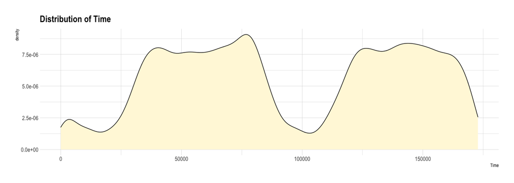

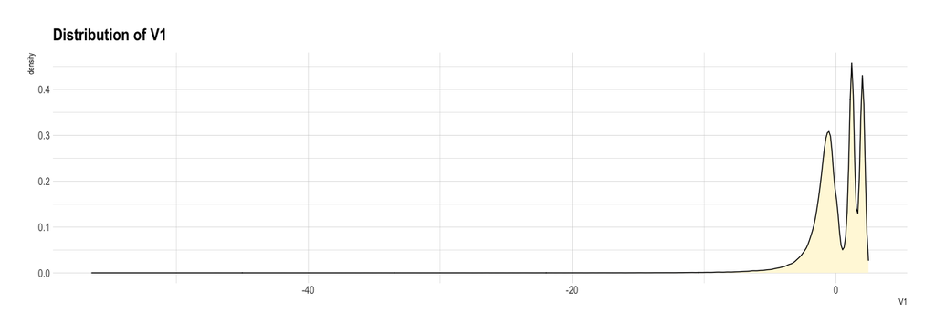

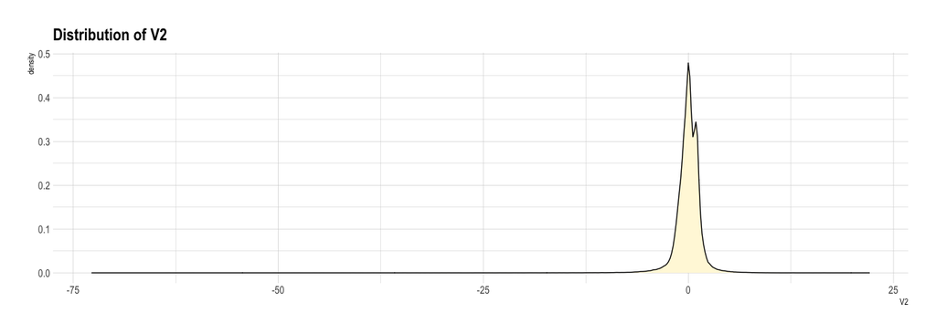

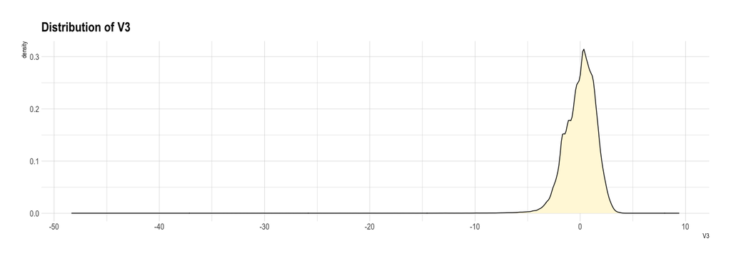

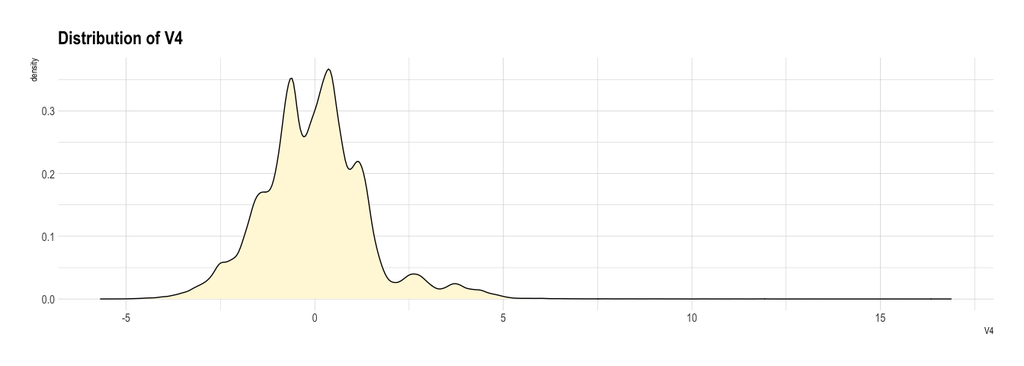

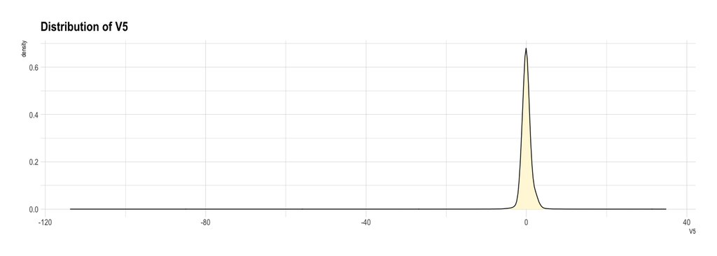

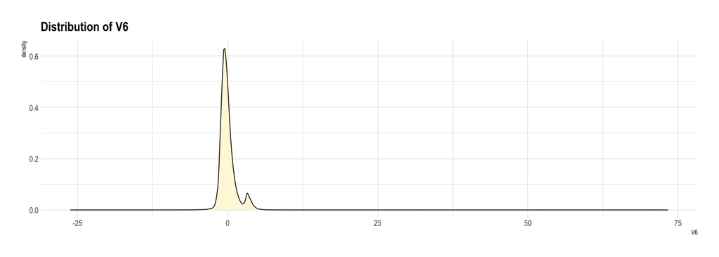

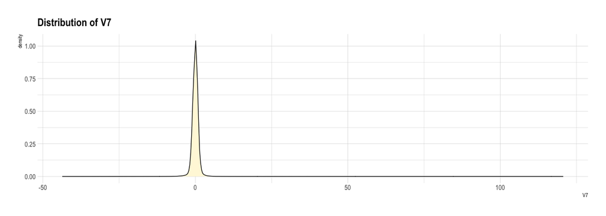

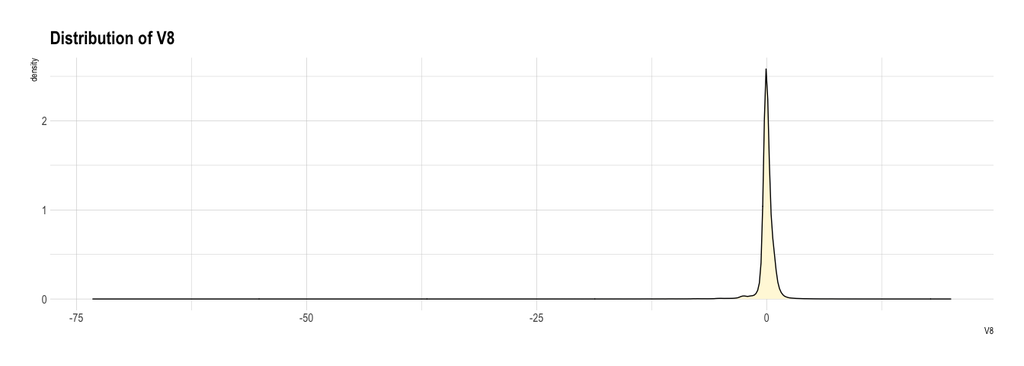

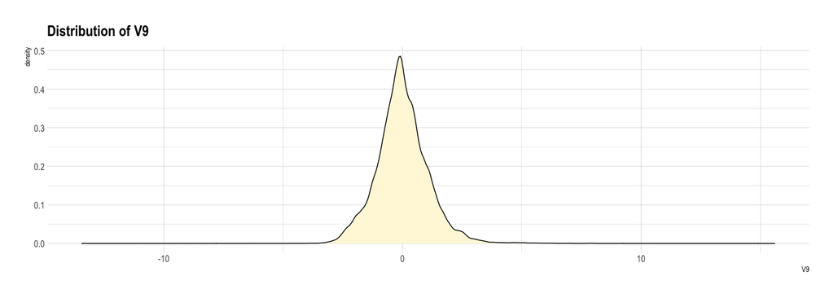

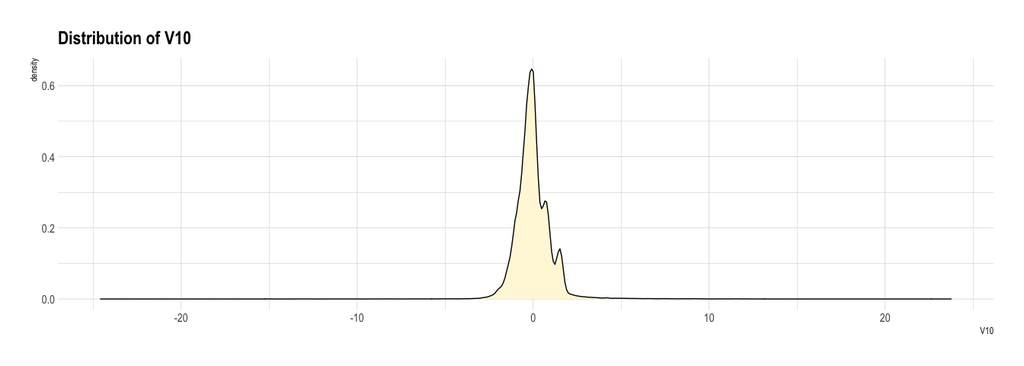

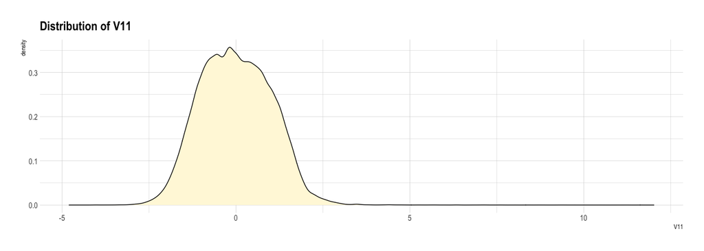

[18 more figures not shown]

```r
for (i in names(credit[, -31])) {
  p <- ggplot(credit, aes_string(x = i)) +
    geom_density(fill = "cornsilk") +
    labs(title = paste0("Distribution of ", i))

  print(p)
}
```

## Relationship with Response

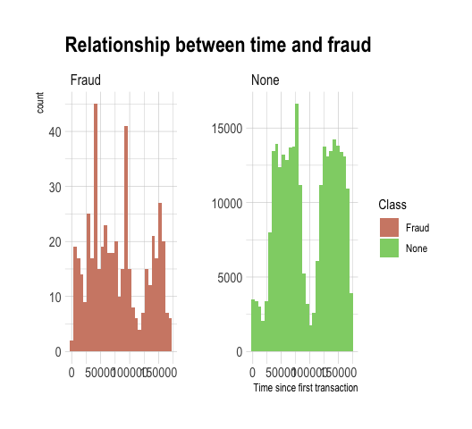

```r
ggplot(data = credit, aes(x = Time, fill = Class)) +
  geom_histogram() +
  facet_wrap(~Class, scales = "free") +
  labs(
    title = "Relationship between time and fraud",
    x = "Time since first transaction") +
  scale_fill_ipsum()
```

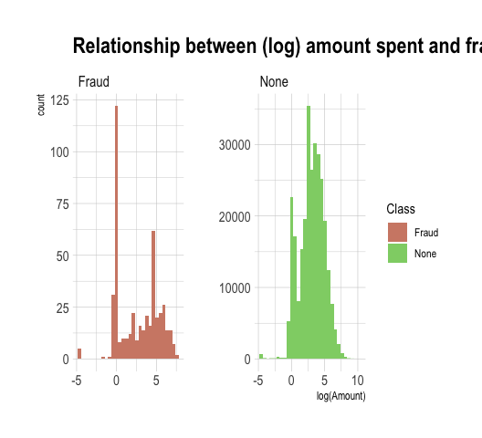

```r
ggplot(data = credit, aes(x = log(Amount), fill = Class)) +
  geom_histogram() +
  facet_wrap(~Class, scales = "free") +
  labs(
    title = "Relationship between (log) amount spent and fraud") +
  scale_fill_ipsum()
```

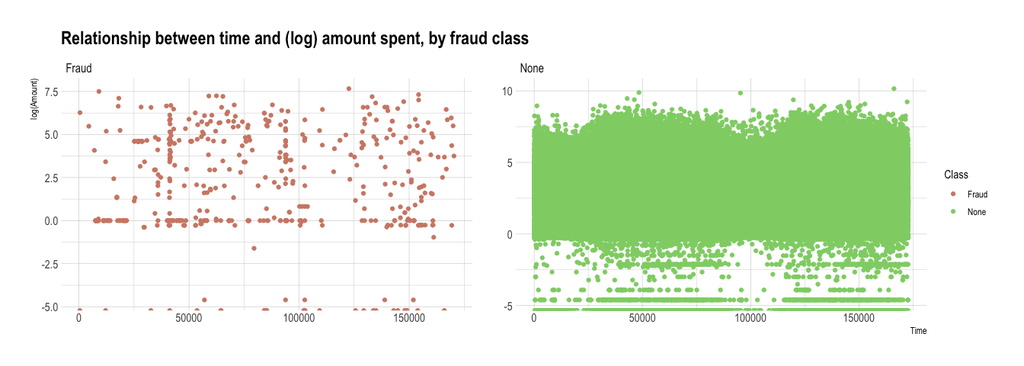

```r
ggplot(data = credit, aes(x = Time, y = log(Amount), color = Class)) +
  geom_point() +
  facet_wrap(~Class, scales = "free")  +
  labs(title = "Relationship between time and (log) amount spent, by fraud class") +
  scale_color_ipsum()
```

There is a clear skew to the `Amount` variable, so it is worth applying a transformation to the data. As there are values of `0`, we need to add `1` to ensure that we don’t get `Inf` values produced after log transformation.

```r
credit <- credit %>%
  mutate(log_amount = log(Amount + 1))

summary(credit$log_amount)
```

```
##    Min. 1st Qu.  Median    Mean 3rd Qu.    Max.
##   0.000   1.887   3.135   3.152   4.359  10.154
```

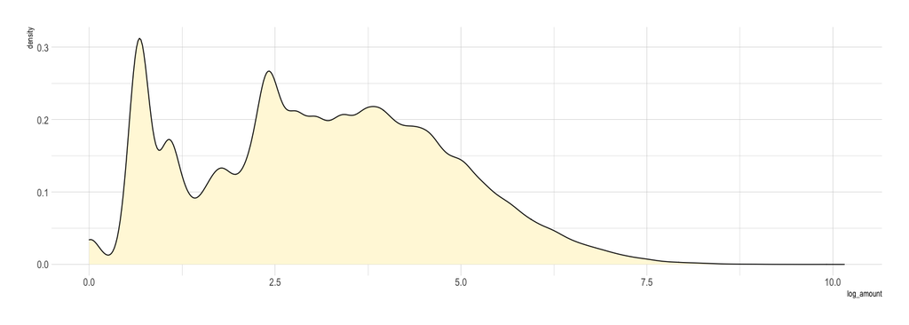

```r
ggplot(credit, aes(x = log_amount)) +
    geom_density(fill = "cornsilk")
```

## Predictor Correlations

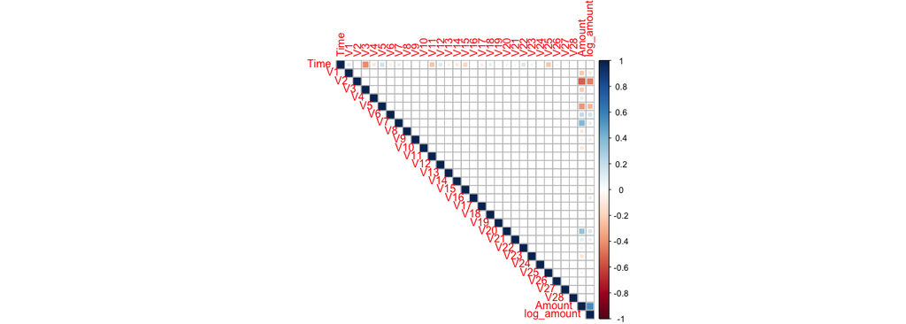

```r
corrplot(cor(credit[, -31]), method = "square", type = "upper")
```

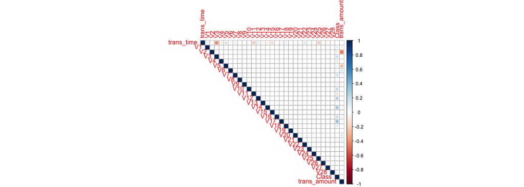

```r
credit %>%
  mutate(
    trans_time = scale(Time, center = TRUE),
    trans_amount = scale(log_amount, center = TRUE)
    ) %>%
  select(trans_time, everything()) %>%
  select(-c(Amount, Time, log_amount)) %>%
  mutate(across(Class, .fns = as.numeric)) %>%
  cor() %>%
  corrplot(method = "square", type = "upper")
```

# PCA Importance

Even though we don’t have the original data for a full exploration of the PCs, we can still look at the importance of the individual PCs in explaining the total variance in the data as we know that the variance observed in each PC is equal to its eigenvalue (https://online.stat.psu.edu/stat505/lesson/11/11.2). Therefore we can still calculate the relative proportions of variance explained, without needed the eigenvalue outputs of the standard `prcomp` function.

```r
vars <- credit %>%
  select(-c(Time, Amount, log_amount, Class)) %>%
  sapply(var) %>%
  sort(decreasing = TRUE) %>%
  as_tibble()

vars
```

```
## # A tibble: 28 x 1
##    value
##    <dbl>
##  1  3.84
##  2  2.73
##  3  2.30
##  4  2.00
##  5  1.91
##  6  1.77
##  7  1.53
##  8  1.43
##  9  1.21
## 10  1.19
## # … with 18 more rows
```

```r
prop_vars <- vars %>%
  transmute(variance = value) %>%
  mutate(prop_var = variance / sum(variance),
         cum_var = cumsum(prop_var),
         PC = fct_inorder(paste0("V", row_number())))

levels(prop_vars$PC)
```

```
##  [1] "V1"  "V2"  "V3"  "V4"  "V5"  "V6"  "V7"  "V8"  "V9"  "V10" "V11" "V12"
## [13] "V13" "V14" "V15" "V16" "V17" "V18" "V19" "V20" "V21" "V22" "V23" "V24"
## [25] "V25" "V26" "V27" "V28"
```

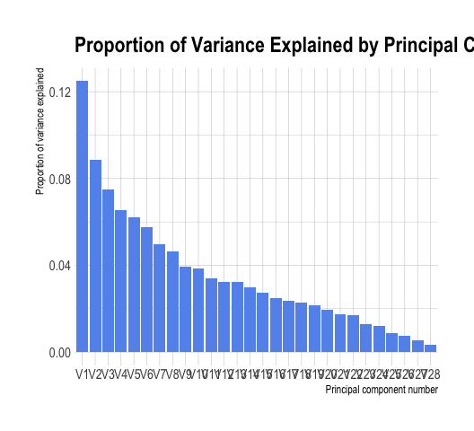

```r
prop_var_plt <- prop_vars %>%
  ggplot(aes(x = PC, y = prop_var)) +
  geom_col(fill = "cornflowerblue") +
  labs(title = "Proportion of Variance Explained by Principal Components",
       x = "Principal component number",
       y = "Proportion of variance explained")

prop_var_plt
```

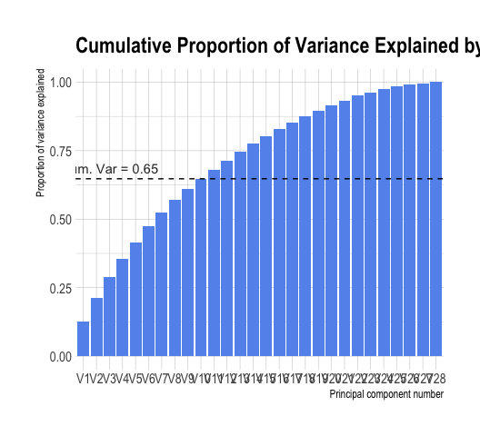

```r
cum_var_plot <- prop_vars %>%
  ggplot(aes(x = PC, y = cum_var)) +
  geom_col(fill = "cornflowerblue") +
  labs(title = "Cumulative Proportion of Variance Explained by Principal Components",
       x = "Principal component number",
       y = "Proportion of variance explained") +
  geom_hline(yintercept = prop_vars$cum_var[10], lty = 2) +
  annotate(geom = "text", x = 3, y = 0.685, label = paste0("Cum. Var = ", round(prop_vars$cum_var[10], 2)), col = "grey20")

cum_var_plot
```

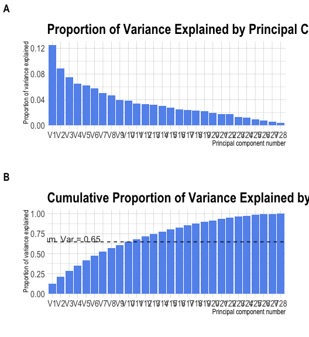

```r
plot_grid(prop_var_plt, cum_var_plot, ncol = 1, labels = c("A", "B"))
```